# Practice portfolio: participant response times

# Purpose and data

This is a **reproducibility practice example**, not a model assessment answer. The code is complete so the report can be rendered from an extracted project. Replace the questions, data, figures and commentary when developing your own portfolio.

The module-provided name-production extract has one row per participant: participant means are across familiarisation conditions. Time measures are milliseconds. The output groups contain different participants. Consult the data dictionary and original study materials before interpreting the supplied vocabulary score. In your own portfolio, cite the original dataset, describe its access and preparation, and explain its suitability.

# Distribution of reaction times

Figure 1 describes the distribution of participant means.

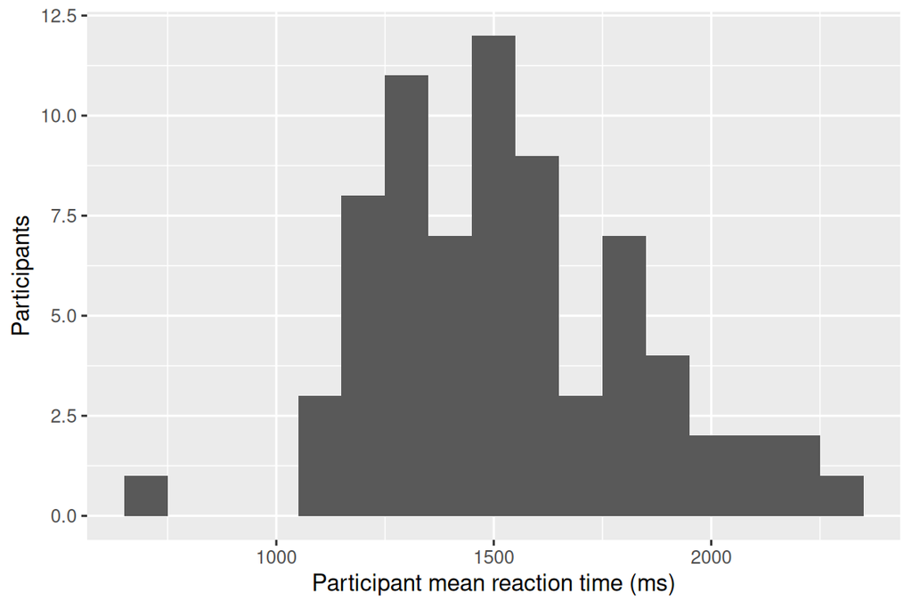

Figure 1: Distribution of participant mean reaction times across both output groups.

```r
ggplot(d, aes(x = mean_rt)) +
  geom_histogram(binwidth = 100) +
  labs(x = "Participant mean reaction time (ms)", y = "Participants")
```

# Reaction times by output group

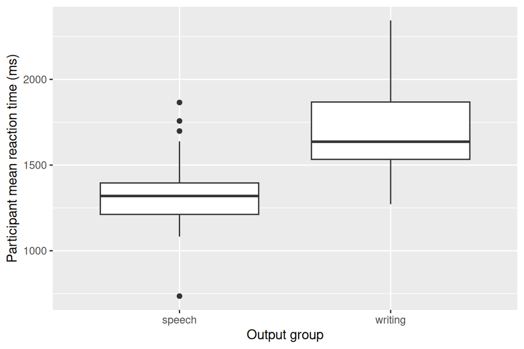

Figure 2: Participant mean reaction times by output group. The groups contain different participants.

```r
ggplot(d, aes(x = modality, y = mean_rt)) +
  geom_boxplot() +
  labs(x = "Output group", y = "Participant mean reaction time (ms)")
```